# [과제5] 임원기

Lim wonki

2019 6 11

## 2015년 서울시 민원 워드클라우드 분석

### **1. 분석 사전 준비**

#### **1.1) 작업 디렉토리 설정**

먼저 민원 데이터가 있는 곳으로 작업 디렉토리를 설정

```
setwd("D:/limworkspace/R_Data_Analysis/Assignment/data/서울시 응답소_2015년전체")
```

#### **1.2) 데이터 준비**

데이터는 2015년 한해 `서울시 응답소`에 올라온 월별 민원 자료를 `응답소_2015_all.txt` 데이터로 통합

#### **1.3) 패키지 준비**

패키지는 다음과 같은 패키지를 사용함

```r
library(rJava)
library(KoNLP)
library(dplyr)
library(stringr)
library(wordcloud)
library(wordcloud2)
```

### **2. 데이터 분석**

#### **2.1) 데이터 불러들이기**

다음의 코드를 통해 2015년 서울시 민원을 모두 불러들이고, 불필요한 `=`기호를 삭제  
코드의 결과가 너무 방대하기 때문에 코드결과를 출력하지 않음

```r
seoul_all_1 <- readLines("응답소_2015_all.txt",encoding="UTF-8") %>% str_remove_all("=")
```

불러들인 `seoul_all_1`데이터에서 `extractNoun`을 이용하여 한글 명사만 추출 한 후  
`list`형태로 `seoul_all_2` 데이터에 저장

```r
seoul_all_2 <- sapply(seoul_all_1, extractNoun, USE.NAMES = F)
```

`unlist`함수를 이용하여 list 형태인 `seoul_all_2`데이터를 vector 형태로 풀기

```r
seoul_all_3 <- unlist(seoul_all_2)
```

#### **2.2) 데이터 전처리**

한글 또는 영문을 제외한 문자 삭제

```r
seoul_all_3 <- str_replace_all(seoul_all_3,"[^[:alpha:]]","")
```

빈칸 삭제

```r
seoul_all_3 <- str_replace_all(seoul_all_3," ","")
```

비슷한 의미의 단어 통합

```r
seoul_all_3 <- str_replace_all(seoul_all_3,"동성애자","동성애")
```

워킹 디렉토리에 `gsubfile.txt` 파일을 생성하고  
데이터에서 필요없다고 판단되는 단어를 삭제

```
gsub_txt <- readLines("gsubfile.txt")

for (i in 1:length(gsub_txt)) {
  seoul_all_3  <- gsub((gsub_txt[i]),"",seoul_all_3)
}
```

마지막으로 문자열의 길이가 2이상인 데이터만 추출

```r
seoul_all_4 <- Filter(function(x) { nchar(x) >= 2 & nchar(x) <= 7 }, seoul_all_3)
```

### **2. 워드 클라우드 생성**

`seoul_all_4`데이터를 `table`로 만들어 빈도를 세고,  
`sort`함수와 `decreasing=T`옵션을 이용해 내림차순 정렬  
빈도가 많은 것부터 45개 단어 출력 * 빈도표 결과

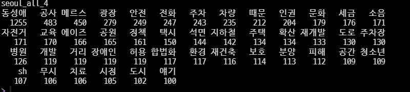

***

```r
wordcount <- head(sort(table(seoul_all_4), decreasing = T),45)
```

`wordcloud2`함수를 이용하면 `wordcloud`보다 시각적으로 나은 워드클라우드 생성

```r
wordcloud2(wordcount, size=0.8,
           col="random-light", backgroundColor="black",
           fontFamily='나눔바른고딕')
```

### **3. 워드클라우드 결과**

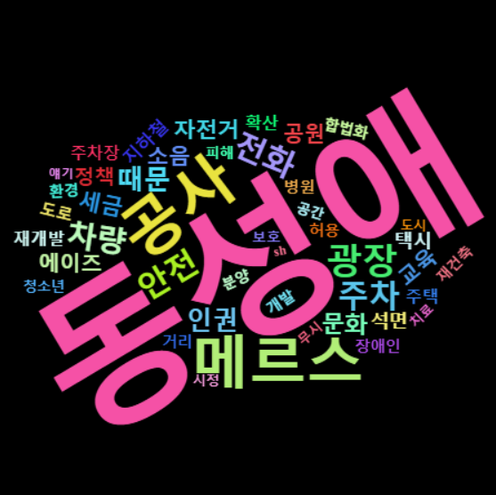